# Optimización e IA 2026-2S

## Práctica 1

### Parte 1: Optimización de funciones usando búsqueda de grilla y búsqueda aleatoria

Departamento de Ciencias de la Computación y de la Decisión  
Facultad de Minas  
Universidad Nacional de Colombia  
Docente: Maria Constanza Torres Madronero

**Elaborado por:** *Kevin Ferney Hidalgo Higuita*

**Correo:** *kfhidalgoh@unal.edu.co*

**Fecha de elaboración:** *12 de septiembre de 2026*

**Fecha última modificación:** *12 de septiembre de 2026*

**Repositorio:**

*Nota: el tema del navegador para visualizar HTML puede afectar el comportamiento de la presentación.*

```python
import sys

import matplotlib.pyplot as plt
import matplotlib.patches as mpatches
import matplotlib.lines as mlines
import numpy as np
from src.utils import logger as log

logger = log.LOGGER
config = log.CONFIG
logger.info("Python %s on %s", sys.version, sys.platform)

%matplotlib inline
rng = np.random.default_rng(123)
```

```
2026-09-16 05:45:49 [INFO] Python 3.14.0 (tags/v3.14.0:ebf955d, Oct  7 2025, 10:15:03) [MSC v.1944 64 bit (AMD64)] on win32
```

Encuentre el valor mínimo de las siguientes funciones empleando la búsqueda por grilla y la aleatoria. Para cada una de las funciones, muestre su gráfica e imprima el valor óptimo.

1. $f\left(x,y\right)=0.26\left(x^{2}+y^{2}-0.48xy\right)\;para\:x,y\in\left[-10,10\right]$
2. $f\left(x,y\right)=-\cos\left(x\right)\cos\left(y\right)\exp\left\{ -\left(\left(x-\pi\right)^{2}+\left(y-\pi\right)^{2}\right)\right\} \;para\:x,y\in\left[-10,10\right]$
3. $f\left(x,y\right)=\left(x^{2}+y-11\right)^{2}+\left(x+y^{2}-7\right)^{2}\;para\:x,y\in\left[-5,5\right]$

## Función objetivo ecuación 1

```python
def f(x: np.ndarray, y: np.ndarray) -> np.ndarray:
    """Calcula el valor de la función f(x, y).

    Args:
        x: Primer argumento, en el intervalo [-10, 10].
        y: Segundo argumento, en el intervalo [-10, 10].

    Returns:
        Valor de f(x, y).

    Raises:
        ValueError: Si x o y están fuera del intervalo [-10, 10].
    """
    if np.any((x < -10) | (x > 10)):
        raise ValueError("Los valores de x deben estar en [-10, 10].")
    if np.any((y < -10) | (y > 10)):
        raise ValueError("Los valores de x deben estar en [-10, 10].")

    return 0.26 * (x**2 + y**2 - 0.48 * x * y)
```

Generación de 100 puntos línealmente espaciados entre -10 y 10

```python
x_lineal = np.linspace(-10, 10, 100)
y_lineal = np.linspace(-10, 10, 100)

X, Y = np.meshgrid(x_lineal, y_lineal)
Z = f(X, Y)


print("\n" + "=" * 45)
print("Evaluación:")
for i in range(5):
    print('f(%.3f, %.3f) = %.3f' % (x_lineal[i], y_lineal[i], Z[i,i]))
print("\n" + "=" * 45)
```

```
=============================================
Evaluación:
f(-10.000, -10.000) = 39.520
f(-9.798, -9.798) = 37.939
f(-9.596, -9.596) = 36.391
f(-9.394, -9.394) = 34.875
f(-9.192, -9.192) = 33.391

=============================================
```

Gráfica

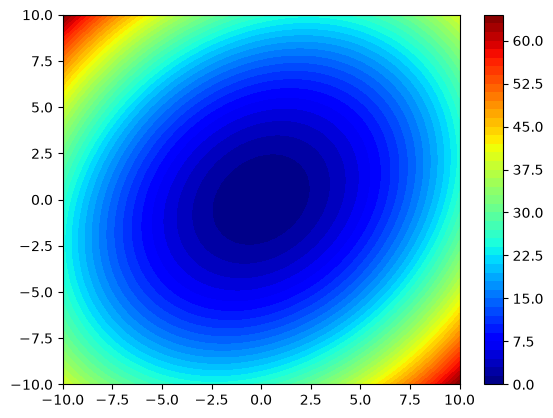

```python
plt.contourf(X, Y, Z, levels=50, cmap=plt.cm.jet)
plt.colorbar()
```

Generación de grilla

```python
x_sample = np.arange(-3.0, 3.0, 0.6)
y_sample = np.arange(-3.0, 3.0, 0.7)

xt, yt = np.meshgrid(x_sample, y_sample)

#Calculamos la funcion
feval_t = f(xt, yt)
```

Busqueda en grilla

```python
# inicializamos variables
f_opt = feval_t[0,0]
best_x, best_y = 0, 0

for i in range(feval_t.shape[0]):  # recorrido en fila
  for j in range(feval_t.shape[1]):  # recorrido en columnas
    if feval_t[i][j]<f_opt:
      f_opt=feval_t[i][j]
      best_x = i
      best_y = j

x_opt = xt[best_x, best_y]
y_opt = yt[best_x, best_y]

print("\n" + "="*35)
print("🏆 RESULTADOS DE LA OPTIMIZACIÓN 🏆")
print("="*35)
print(f"🔸 Coordenada X : {x_opt:.5f}")
print(f"🔸 Coordenada Y : {y_opt:.5f}")
print("-" * 35)
print(f"🎯 Valor Óptimo : {f_opt:.5f}")
print("="*35 + "\n")
```

```
===================================
🏆 RESULTADOS DE LA OPTIMIZACIÓN 🏆
===================================
🔸 Coordenada X : 0.00000
🔸 Coordenada Y : -0.20000
-----------------------------------
🎯 Valor Óptimo : 0.01040
===================================
```

gráfica

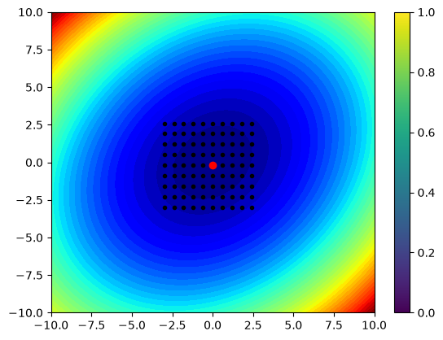

```python
plt.contourf(X, Y, Z, levels=50, cmap='jet')
plt.scatter(xt,yt,c='black',marker='.')
plt.scatter(xt[best_x][best_y],yt[best_x][best_y],c='red')
plt.colorbar()
```

Búsqueda con puntos aleatorios

```python
r_min, r_max = -3.0, 3.0
x_sample = r_min + rng.random(200) * (r_max - r_min)
y_sample = r_min + rng.random(200) * (r_max - r_min)

x_t, y_t = np.meshgrid(x_sample, y_sample)

#Calculamos la funcion
feval_t=f(x_t,y_t)
```

Búsqueda valor óptimo

```python
f_opt = feval_t[0][0]
for i in range(feval_t.shape[0]):
  for j in range(feval_t.shape[1]):
    if feval_t[i][j]<f_opt:
      f_opt=feval_t[i][j]
      best_x = i
      best_y = j


x_opt = x_t[best_x, best_y]
y_opt = y_t[best_x, best_y]

print("\n" + "="*35)
print("🏆 RESULTADOS DE LA OPTIMIZACIÓN 🏆")
print("="*35)
print(f"🔸 Coordenada X : {x_opt:.5f}")
print(f"🔸 Coordenada Y : {y_opt:.5f}")
print("-" * 35)
print(f"🎯 Valor Óptimo : {f_opt:.5f}")
print("="*35 + "\n")
```

```
===================================
🏆 RESULTADOS DE LA OPTIMIZACIÓN 🏆
===================================
🔸 Coordenada X : -0.00308
🔸 Coordenada Y : 0.03523
-----------------------------------
🎯 Valor Óptimo : 0.00034
===================================
```

gráfica grilla aleatoria

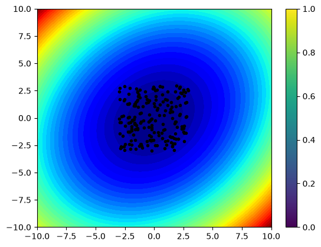

```python
plt.contourf(X, Y, Z, levels=50, cmap='jet')
plt.scatter(x_sample,y_sample,c='black',marker='.')
plt.colorbar()
```

## Función objetivo ecuación 2

```python
def f2(x: np.ndarray, y: np.ndarray) -> np.ndarray:
    """Calcula la función de forma vectorizada.

    Args:
        x: Valores de x en el intervalo [-10, 10].
        y: Valores de y en el intervalo [-10, 10].

    Returns:
        Valores de la función para cada par de x e y.
    """
    return -np.cos(x) * np.cos(y) * np.exp(
        -((x - np.pi) ** 2 + (y - np.pi) ** 2)
    )
```

Generación de 100 puntos línealmente espaciados entre -10 y 10

```python
x2_lineal = np.linspace(-10, 10, 100)
y2_lineal = np.linspace(-10, 10, 100)

X_2, Y_2 = np.meshgrid(x2_lineal, y2_lineal)
Z_2 = f2(X_2, Y_2)


print("\n" + "=" * 45)
print("Evaluación:")
for i in range(5):
    print('f(%.3f, %.3f) = %.3f' % (x2_lineal[i], y2_lineal[i], Z[i,i]))
print("\n" + "=" * 45)
```

```
=============================================
Evaluación:
f(-10.000, -10.000) = 39.520
f(-9.798, -9.798) = 37.939
f(-9.596, -9.596) = 36.391
f(-9.394, -9.394) = 34.875
f(-9.192, -9.192) = 33.391

=============================================
```

Gráfica de contorno

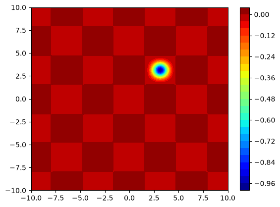

```python
plt.contourf(X_2, Y_2, Z_2, levels=30, cmap=plt.cm.jet)
plt.colorbar()
```

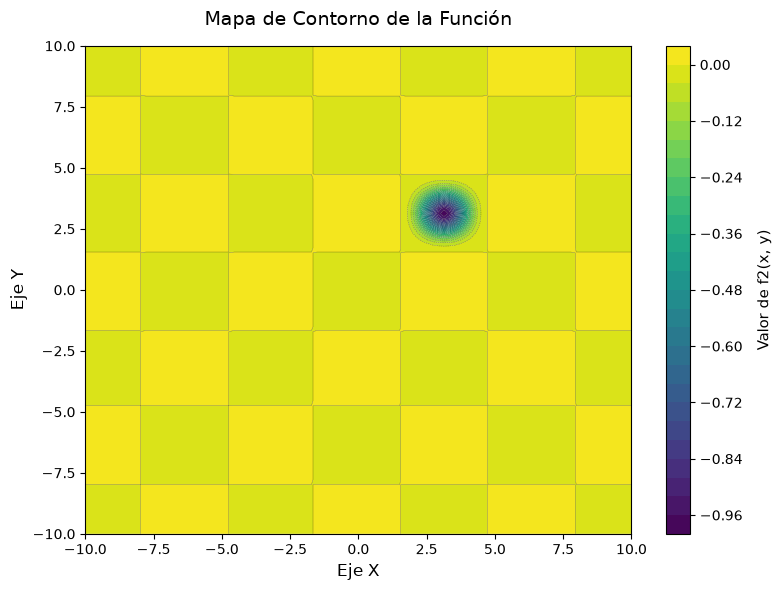

```python
fig, ax = plt.subplots(figsize=(8, 6), dpi=100)

contorno = ax.contourf(X_2, Y_2, Z_2, levels=30, cmap='viridis', antialiased=True)

cbar = fig.colorbar(contorno, ax=ax)
cbar.set_label('Valor de f2(x, y)', fontsize=11, labelpad=10)

ax.set_title('Mapa de Contorno de la Función', fontsize=14, pad=15)
ax.set_xlabel('Eje X', fontsize=12)
ax.set_ylabel('Eje Y', fontsize=12)

ax.contour(X_2, Y_2, Z_2, levels=30, colors='black', linewidths=0.3, alpha=0.5)

fig.tight_layout()

plt.show()
```

Se observa que se encuentra en el intervalo [1, 5] crearemos los puntos en este intervalo para que la gráfica quede con zoom

```python
x2_1_lineal = np.linspace(1, 5, 200)
y2_1_lineal = np.linspace(1, 5, 200)

X_2_1, Y_2_1 = np.meshgrid(x2_1_lineal, y2_1_lineal)
Z_2_1 = f2(X_2_1, Y_2_1)
```

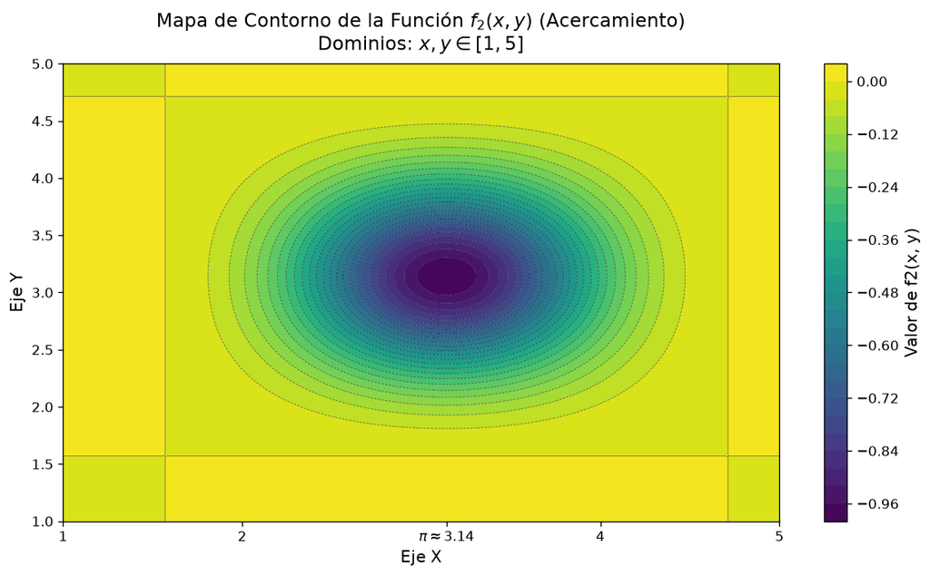

```python
fig, ax = plt.subplots(figsize=(10, 6), dpi=120)

# contornos rellenos y líneas de contorno
contorno_relleno = ax.contourf(X_2_1, Y_2_1, Z_2_1, levels=30, cmap='viridis', antialiased=True)
contorno_lineas = ax.contour(X_2_1, Y_2_1, Z_2_1, levels=30, colors='black', linewidths=0.5, alpha=0.5)

# Barra de color
cbar = fig.colorbar(contorno_relleno, ax=ax)
cbar.set_label('Valor de f2(x, y)', fontsize=12)

# Modificar las marcas (ticks) del eje X para incluir a Pi
ax.set_xticks([1, 2, np.pi, 4, 5])
ax.set_xticklabels(['1', '2', '$\pi\\approx3.14$', '4', '5'])

# Etiquetas y título
ax.set_xlabel('Eje X', fontsize=12)
ax.set_ylabel('Eje Y', fontsize=12)
ax.set_title('Mapa de Contorno de la Función $f_2(x, y)$ (Acercamiento)\nDominios: $x, y \in [1, 5]$', fontsize=14, pad=10)

# Ajustar márgenes y mostrar
fig.tight_layout()
plt.show()
```

El mínimo parece darse en [$\pi, $\pi] ahora vamos a buscar generar la grilla

```python
x_sample = np.arange(1.0, 5.0, 0.5)
y_sample = np.arange(1.0, 5.0, 0.5)

xt, yt = np.meshgrid(x_sample, y_sample)

#Calculamos la funcion
feval_t = f2(xt, yt)
```

Busqueda en grilla

```python
# Encontrar el índice (plano) del valor mínimo en la matriz
indice_minimo = np.argmin(feval_t)

# Convertir ese índice plano en coordenadas de fila y columna (best_x, best_y)
best_x, best_y = np.unravel_index(indice_minimo, feval_t.shape)

# Extraer los valores
f_opt = feval_t[best_x, best_y]
x_opt = xt[best_x, best_y]
y_opt = yt[best_x, best_y]

print("\n" + "="*35)
print("🏆 RESULTADOS DE LA OPTIMIZACIÓN 🏆")
print("="*35)
print(f"🔸 Coordenada X : {x_opt:.5f}")
print(f"🔸 Coordenada Y : {y_opt:.5f}")
print("-" * 35)
print(f"🎯 Valor Óptimo : {f_opt:.5f}")
print("="*35 + "\n")
```

```
===================================
🏆 RESULTADOS DE LA OPTIMIZACIÓN 🏆
===================================
🔸 Coordenada X : 3.00000
🔸 Coordenada Y : 3.00000
-----------------------------------
🎯 Valor Óptimo : -0.94156
===================================
```

Gráfica con la grilla

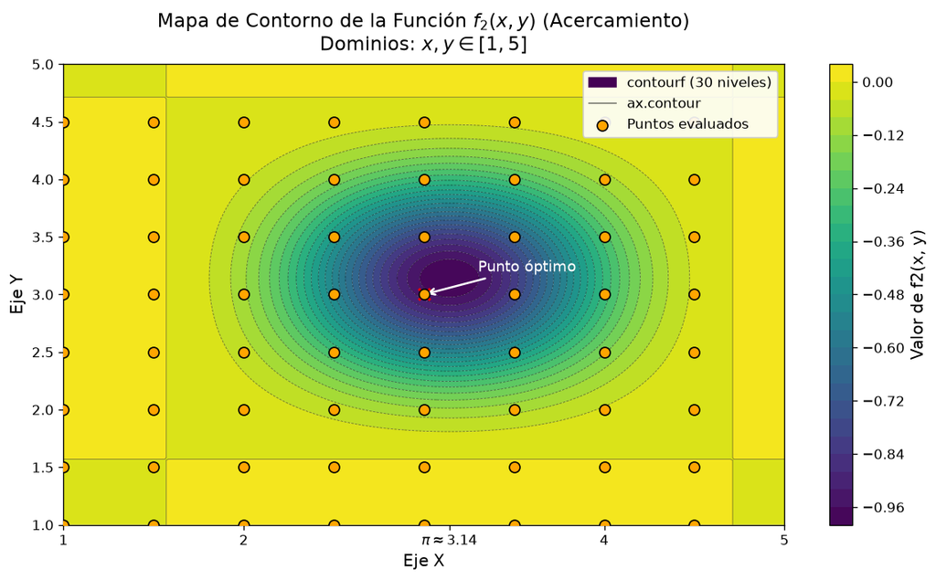

```python
fig, ax = plt.subplots(figsize=(10, 6), dpi=120)

# contornos rellenos y líneas de contorno
contorno_relleno = ax.contourf(X_2_1, Y_2_1, Z_2_1, levels=30, cmap='viridis', antialiased=True)
contorno_lineas = ax.contour(X_2_1, Y_2_1, Z_2_1, levels=30, colors='black', linewidths=0.5, alpha=0.5)

# Barra de color
cbar = fig.colorbar(contorno_relleno, ax=ax)
cbar.set_label('Valor de f2(x, y)', fontsize=12)

# grilla
puntos_scatter = ax.scatter(
    xt, yt, color='orange',
    edgecolors='black', s=60, zorder=5,
    label='Puntos evaluados'
)

# punto óptimo
ax.plot(x_opt, y_opt, 'rx', markersize=8, markeredgewidth=2)
ax.annotate(
    'Punto óptimo',
    xy=(x_opt, y_opt),
    xytext=(x_opt + 0.3, y_opt + 0.2),
    color='white',
    fontsize=11,
    arrowprops=dict(arrowstyle="->", color='white', lw=1.5)
)

# Modificar las marcas (ticks) del eje X para incluir a Pi
ax.set_xticks([1, 2, np.pi, 4, 5])
ax.set_xticklabels(['1', '2', '$\pi\\approx3.14$', '4', '5'])

# Etiquetas y título
ax.set_xlabel('Eje X', fontsize=12)
ax.set_ylabel('Eje Y', fontsize=12)
ax.set_title('Mapa de Contorno de la Función $f_2(x, y)$ (Acercamiento)\nDominios: $x, y \in [1, 5]$', fontsize=14, pad=10)
parche_color = mpatches.Patch(color=contorno_relleno.cmap(0), label='contourf (30 niveles)')
linea_ejemplo = mlines.Line2D([], [], color='black', alpha=0.5, linewidth=1, label='ax.contour')

ax.legend(handles=[parche_color, linea_ejemplo, puntos_scatter], loc='upper right', framealpha=0.9)

# Ajustar márgenes y mostrar
fig.tight_layout()
plt.show()
```

Búsqueda con puntos aleatorios

```python
r_min, r_max = 1.0, 5.0
x_sample = r_min + rng.random(20) * (r_max - r_min)
y_sample = r_min + rng.random(20) * (r_max - r_min)

x_t, y_t = np.meshgrid(x_sample, y_sample)

#Calculamos la funcion
feval_t=f2(x_t,y_t)
```

Valor óptimo

```python
# Encontrar el índice (plano) del valor mínimo en la matriz
indice_minimo = np.argmin(feval_t)

# Convertir ese índice plano en coordenadas de fila y columna (best_x, best_y)
best_x, best_y = np.unravel_index(indice_minimo, feval_t.shape)

# Extraer los valores
f_opt = feval_t[best_x, best_y]
x_opt = x_t[best_x, best_y]
y_opt = y_t[best_x, best_y]

print("\n" + "="*35)
print("🏆 RESULTADOS DE LA OPTIMIZACIÓN 🏆")
print("="*35)
print(f"🔸 Coordenada X : {x_opt:.5f}")
print(f"🔸 Coordenada Y : {y_opt:.5f}")
print("-" * 35)
print(f"🎯 Valor Óptimo : {f_opt:.5f}")
print("="*35 + "\n")
```

```
===================================
🏆 RESULTADOS DE LA OPTIMIZACIÓN 🏆
===================================
🔸 Coordenada X : 3.05419
🔸 Coordenada Y : 3.08821
-----------------------------------
🎯 Valor Óptimo : -0.98439
===================================
```

Gráfica grilla aleatoria

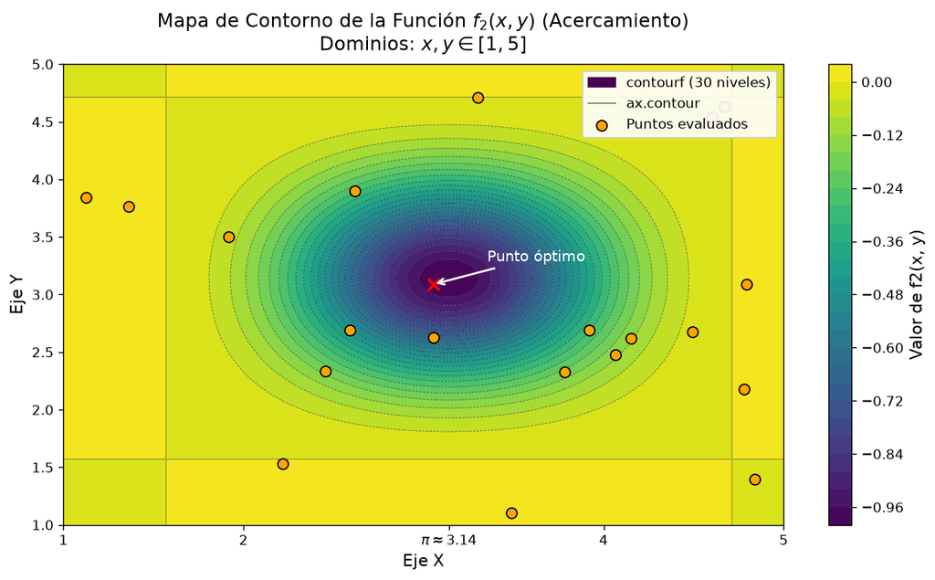

```python
fig, ax = plt.subplots(figsize=(10, 6), dpi=120)

# contornos rellenos y líneas de contorno
contorno_relleno = ax.contourf(X_2_1, Y_2_1, Z_2_1, levels=30, cmap='viridis', antialiased=True)
contorno_lineas = ax.contour(X_2_1, Y_2_1, Z_2_1, levels=30, colors='black', linewidths=0.5, alpha=0.5)

# Barra de color
cbar = fig.colorbar(contorno_relleno, ax=ax)
cbar.set_label('Valor de f2(x, y)', fontsize=12)

# grilla
puntos_scatter = ax.scatter(
    x_sample, y_sample, color='orange',
    edgecolors='black', s=60, zorder=5,
    label='Puntos evaluados'
)

# punto óptimo
ax.plot(x_opt, y_opt, 'rx', markersize=8, markeredgewidth=2)
ax.annotate(
    'Punto óptimo',
    xy=(x_opt, y_opt),
    xytext=(x_opt + 0.3, y_opt + 0.2),
    color='white',
    fontsize=11,
    arrowprops=dict(arrowstyle="->", color='white', lw=1.5)
)

# Modificar las marcas (ticks) del eje X para incluir a Pi
ax.set_xticks([1, 2, np.pi, 4, 5])
ax.set_xticklabels(['1', '2', '$\pi\\approx3.14$', '4', '5'])

# Etiquetas y título
ax.set_xlabel('Eje X', fontsize=12)
ax.set_ylabel('Eje Y', fontsize=12)
ax.set_title('Mapa de Contorno de la Función $f_2(x, y)$ (Acercamiento)\nDominios: $x, y \in [1, 5]$', fontsize=14, pad=10)
parche_color = mpatches.Patch(color=contorno_relleno.cmap(0), label='contourf (30 niveles)')
linea_ejemplo = mlines.Line2D([], [], color='black', alpha=0.5, linewidth=1, label='ax.contour')

ax.legend(handles=[parche_color, linea_ejemplo, puntos_scatter], loc='upper right', framealpha=0.9)

# Ajustar márgenes y mostrar
fig.tight_layout()
plt.show()
```

## Función objetivo ecuación 3

```python
def f3(x: float | np.ndarray, y: float | np.ndarray) -> float | np.ndarray:
    """Calcula la función de vectorizada.

    Esta función matemática se define como:
    f(x, y) = (x**2 + y - 11)**2 + (x + y**2 - 7)**2
    El dominio estándar de evaluación suele ser x, y ∈ [-5, 5].

    Args:
        x (float o numpy.ndarray): Coordenada o arreglo de coordenadas en el eje X.
        y (float o numpy.ndarray): Coordenada o arreglo de coordenadas en el eje Y.

    Returns:
        float o numpy.ndarray: El valor o arreglo de valores resultantes
        tras evaluar la función.
    """
    return (x**2 + y - 11)**2 + (x + y**2 - 7)**2
```

```python
x_lineal = np.linspace(-5, 5, 100)
y_lineal = np.linspace(-5, 5, 100)

X, Y = np.meshgrid(x_lineal, y_lineal)

Z = f3(X, Y)

print("\n" + "=" * 45)
print("Evaluación:")
for i in range(5):
    print('f(%.3f, %.3f) = %.3f' % (x2_lineal[i], y2_lineal[i], Z[i,i]))
print("\n" + "=" * 45)
```

```
=============================================
Evaluación:
f(-10.000, -10.000) = 250.000
f(-9.798, -9.798) = 212.065
f(-9.596, -9.596) = 178.114
f(-9.394, -9.394) = 147.932
f(-9.192, -9.192) = 121.308

=============================================
```

Gráfica de contorno

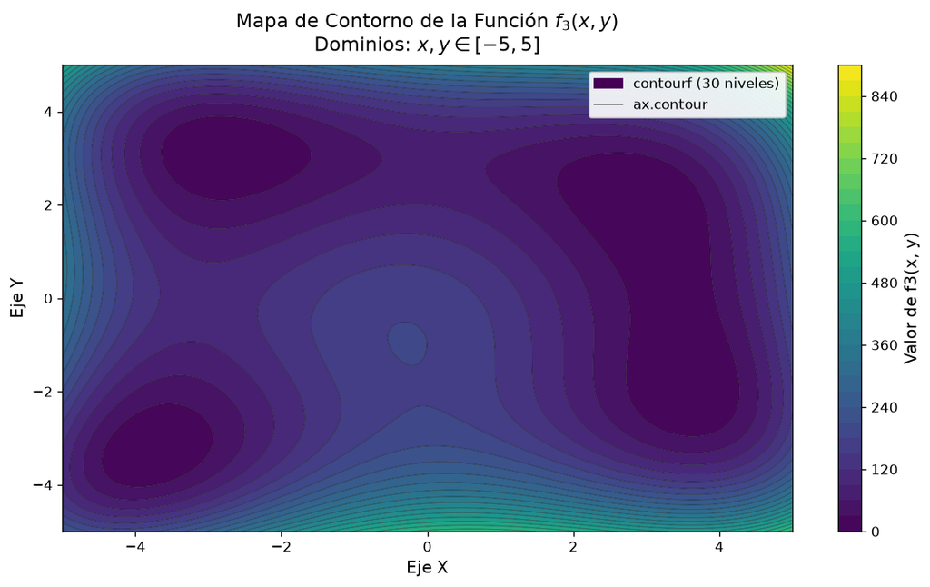

```python
fig, ax = plt.subplots(figsize=(10, 6), dpi=120)

# contornos rellenos y líneas de contorno
contorno_relleno = ax.contourf(X, Y, Z, levels=30, cmap='viridis', antialiased=True)
contorno_lineas = ax.contour(X, Y, Z, levels=30, colors='black', linewidths=0.5, alpha=0.5)

# Barra de color
cbar = fig.colorbar(contorno_relleno, ax=ax)
cbar.set_label('Valor de f3(x, y)', fontsize=12)

# Etiquetas y título
ax.set_xlabel('Eje X', fontsize=12)
ax.set_ylabel('Eje Y', fontsize=12)
ax.set_title('Mapa de Contorno de la Función $f_3(x, y)$\nDominios: $x, y \in [-5, 5]$', fontsize=14, pad=10)
parche_color = mpatches.Patch(color=contorno_relleno.cmap(0), label='contourf (30 niveles)')
linea_ejemplo = mlines.Line2D([], [], color='black', alpha=0.5, linewidth=1, label='ax.contour')

ax.legend(handles=[parche_color, linea_ejemplo], loc='upper right', framealpha=0.9)

# Ajustar márgenes y mostrar
fig.tight_layout()
plt.show()
```

Podemos tener varios mínimos, generación de la grilla

```python
x_sample = np.arange(-5.0, 5.0, 1)
y_sample = np.arange(-5.0, 5.0, 1)

xt, yt = np.meshgrid(x_sample, y_sample)

# Calculamos la función
feval_t = f2(xt, yt)
```

Búsqueda en la cuadrícula

```python
indice_minimo = np.argmin(feval_t)

best_x, best_y = np.unravel_index(indice_minimo, feval_t.shape)

f_opt = feval_t[best_x, best_y]
x_opt = xt[best_x, best_y]
y_opt = yt[best_x, best_y]

print("\n" + "="*35)
print("🏆 RESULTADOS DE LA OPTIMIZACIÓN 🏆")
print("="*35)
print(f"🔸 Coordenada X : {x_opt:.5f}")
print(f"🔸 Coordenada Y : {y_opt:.5f}")
print("-" * 35)
print(f"🎯 Valor Óptimo : {f_opt:.5f}")
print("="*35 + "\n")
```

```
===================================
🏆 RESULTADOS DE LA OPTIMIZACIÓN 🏆
===================================
🔸 Coordenada X : 3.00000
🔸 Coordenada Y : 3.00000
-----------------------------------
🎯 Valor Óptimo : -0.94156
===================================
```

Gráfica contorno con cuadrícula

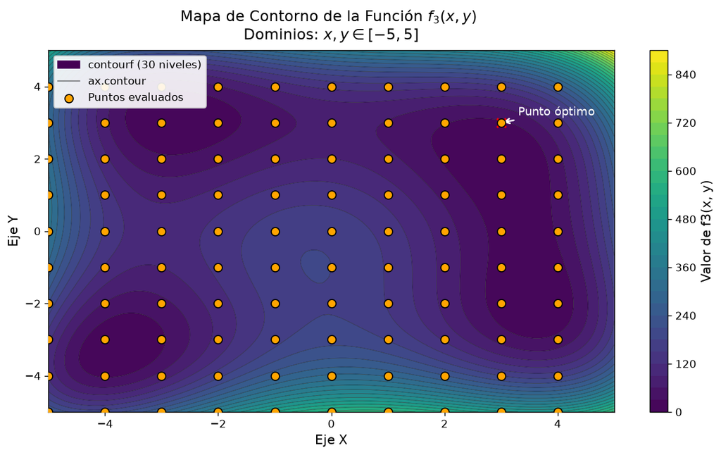

```python
fig, ax = plt.subplots(figsize=(10, 6), dpi=120)

# contornos rellenos y líneas de contorno
contorno_relleno = ax.contourf(X, Y, Z, levels=30, cmap='viridis', antialiased=True)
contorno_lineas = ax.contour(X, Y, Z, levels=30, colors='black', linewidths=0.5, alpha=0.5)

# Barra de color
cbar = fig.colorbar(contorno_relleno, ax=ax)
cbar.set_label('Valor de f3(x, y)', fontsize=12)

# grilla
puntos_scatter = ax.scatter(
    xt, yt, color='orange',
    edgecolors='black', s=60, zorder=5,
    label='Puntos evaluados'
)

# punto óptimo
ax.plot(x_opt, y_opt, 'rx', markersize=8, markeredgewidth=2)
ax.annotate(
    'Punto óptimo',
    xy=(x_opt, y_opt),
    xytext=(x_opt + 0.3, y_opt + 0.2),
    color='white',
    fontsize=11,
    arrowprops=dict(arrowstyle="->", color='white', lw=1.5)
)

# Etiquetas y título
ax.set_xlabel('Eje X', fontsize=12)
ax.set_ylabel('Eje Y', fontsize=12)
ax.set_title('Mapa de Contorno de la Función $f_3(x, y)$ \nDominios: $x, y \in [-5, 5]$', fontsize=14, pad=10)
parche_color = mpatches.Patch(color=contorno_relleno.cmap(0), label='contourf (30 niveles)')
linea_ejemplo = mlines.Line2D([], [], color='black', alpha=0.5, linewidth=1, label='ax.contour')

ax.legend(handles=[parche_color, linea_ejemplo, puntos_scatter], loc='upper left', framealpha=0.9)

# Ajustar márgenes y mostrar
fig.tight_layout()
plt.show()
```

Búsqueda con puntos aleatorios

```python
r_min, r_max = -5.0, 5.0
x_sample = r_min + rng.random(200) * (r_max - r_min)
y_sample = r_min + rng.random(200) * (r_max - r_min)

x_t, y_t = np.meshgrid(x_sample, y_sample)

#Calculamos la funcion
feval_t=f3(x_t,y_t)
```

Búsqueda en la grilla aleatoria

```python
indice_minimo = np.argmin(feval_t)

best_x, best_y = np.unravel_index(indice_minimo, feval_t.shape)

f_opt = feval_t[best_x, best_y]
x_opt = x_t[best_x, best_y]
y_opt = y_t[best_x, best_y]

print("\n" + "="*35)
print("🏆 RESULTADOS DE LA OPTIMIZACIÓN 🏆")
print("="*35)
print(f"🔸 Coordenada X : {x_opt:.5f}")
print(f"🔸 Coordenada Y : {y_opt:.5f}")
print("-" * 35)
print(f"🎯 Valor Óptimo : {f_opt:.5f}")
print("="*35 + "\n")
```

```
===================================
🏆 RESULTADOS DE LA OPTIMIZACIÓN 🏆
===================================
🔸 Coordenada X : -2.79877
🔸 Coordenada Y : 3.14631
-----------------------------------
🎯 Valor Óptimo : 0.01052
===================================
```

Gráfica con grilla aleatoria

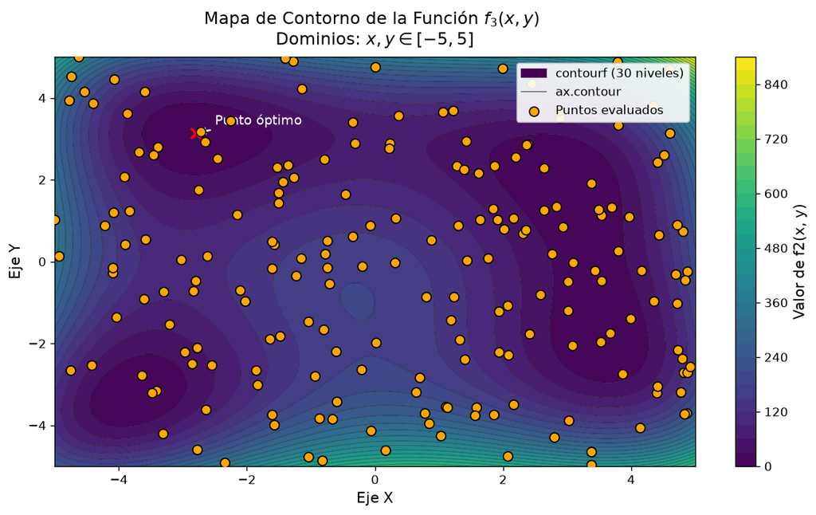

```python
fig, ax = plt.subplots(figsize=(10, 6), dpi=120)

# contornos rellenos y líneas de contorno
contorno_relleno = ax.contourf(X, Y, Z, levels=30, cmap='viridis', antialiased=True)
contorno_lineas = ax.contour(X, Y, Z, levels=30, colors='black', linewidths=0.5, alpha=0.5)

# Barra de color
cbar = fig.colorbar(contorno_relleno, ax=ax)
cbar.set_label('Valor de f2(x, y)', fontsize=12)

# grilla
puntos_scatter = ax.scatter(
    x_sample, y_sample, color='orange',
    edgecolors='black', s=60, zorder=5,
    label='Puntos evaluados'
)

# punto óptimo
ax.plot(x_opt, y_opt, 'rx', markersize=8, markeredgewidth=2)
ax.annotate(
    'Punto óptimo',
    xy=(x_opt, y_opt),
    xytext=(x_opt + 0.3, y_opt + 0.2),
    color='white',
    fontsize=11,
    arrowprops=dict(arrowstyle="->", color='white', lw=1.5)
)

# Etiquetas y título
ax.set_xlabel('Eje X', fontsize=12)
ax.set_ylabel('Eje Y', fontsize=12)
ax.set_title('Mapa de Contorno de la Función $f_3(x, y)$ \nDominios: $x, y \in [-5, 5]$', fontsize=14, pad=10)
parche_color = mpatches.Patch(color=contorno_relleno.cmap(0), label='contourf (30 niveles)')
linea_ejemplo = mlines.Line2D([], [], color='black', alpha=0.5, linewidth=1, label='ax.contour')

ax.legend(handles=[parche_color, linea_ejemplo, puntos_scatter], loc='upper right', framealpha=0.9)

# Ajustar márgenes y mostrar
fig.tight_layout()
plt.show()
```